# Codes of the manuscript: Analysis and simulation of plant disease progress curves in R: introducing the epifitter package

Kaique Alves & Emerson Del Ponte

22/09/2020

# Loading the packages needed to run these analysis

```r
library(epifitter)
library(tidyverse)
library(cowplot)
library(gsheet)
library(patchwork)
library(ggthemes)
library(multcomp)
library(emmeans)
```

# Load data Actual data

Here we load the data from a google sheets using the function `gsheet2tbl()` from the package `gsheet`.

```r
data_load0 = gsheet2tbl("https://docs.google.com/spreadsheets/d/1SPAykaTw9tlcNALRMlSecaZQYQECTTaQtri2Lh3DSfo/edit#gid=0")
```

# Wragling data

This dataset contains data of disease progress curves of powdery mildew and Lata blight in tomato. However we are going to work only with powdery mildew. We also convert severity to proportion (0-1); Filter only the last year of evaluation; Transform days after planting to days after first disease evaluation; and change the name of the levels of moisture to be clearer in the graphs.

```r
data_load = data_load0%>%
  #removing Late blight part of the data.
filter(disease != "Late blight",
         irrigation_type != "Drip + Microsprinkler in alternate application",
         irrigation_type != "Drip + Microsprinkler as P.Mildew control",
         ) %>%
  #converting severity to proportion
  mutate(sev = sev/100) %>%

  #filter only the data from 2011
  filter(year =="2011") %>%

  #convert dap to days after first evaluation
  mutate(time = dap - min(dap)) %>%
  #remove the dap column
  dplyr::select(-dap) %>%

  #Change the name of the levels of moisture for clarification
  mutate(moisture = case_when(moisture == "High" ~ "High moisture",
                              moisture == "Moderate" ~ "Moderate moisture"))

head(data_load)
```

| disease | year | trat | irrigation_type | moisture | block | sev | time |
| --- | --- | --- | --- | --- | --- | --- | --- |
| Powdery mildew | 2011 | 1 | Drip | High moisture | 1 | 0.011 | 0 |
| Powdery mildew | 2011 | 1 | Drip | High moisture | 2 | 0.011 | 0 |
| Powdery mildew | 2011 | 1 | Drip | High moisture | 3 | 0.011 | 0 |
| Powdery mildew | 2011 | 1 | Drip | High moisture | 1 | 0.034 | 7 |
| Powdery mildew | 2011 | 1 | Drip | High moisture | 2 | 0.040 | 7 |
| Powdery mildew | 2011 | 1 | Drip | High moisture | 3 | 0.036 | 7 |

# Visualization

Here we use `ggplot2` functions to produce the graph of the powdery mildew epidemics for each treatment (combination of irrigation system and moisture levels in the soil)

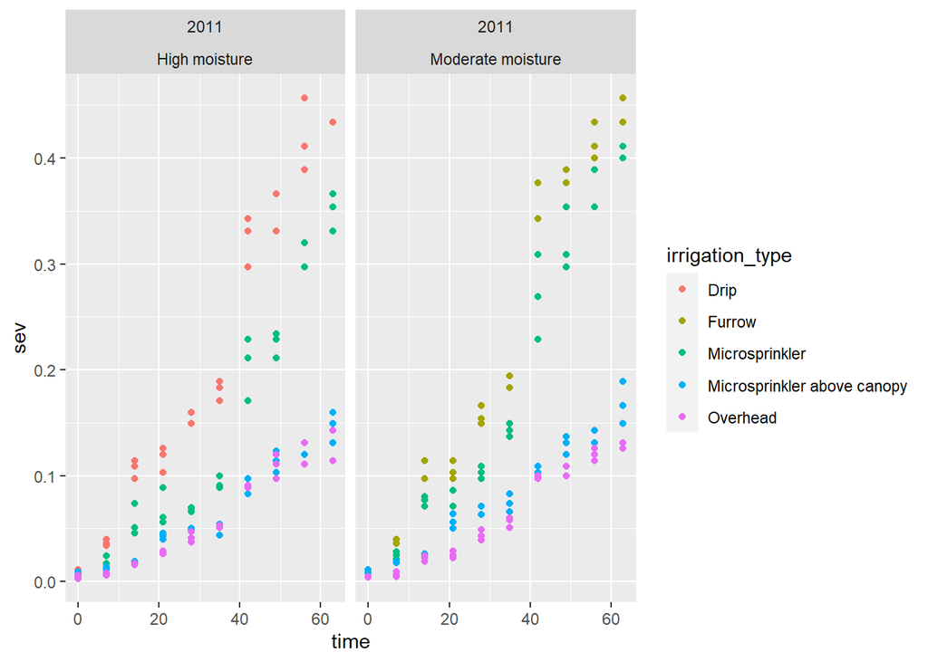

```r
data_load %>%
  ggplot(aes(time, sev, color =  irrigation_type))+
  geom_point()+
  # stat_summary()+
  # geom_smooth(se = F)+
  facet_wrap(year~moisture)
```

### AUDPC and AUDPS using epifitter

The area under the disease progress curves and disease progress stais were calculated using the `AUDPC()` and `AUDPS()` fruntion from `epifitter` in the `summarise()` funtion from `dplyr()`.

```r
auc_data = data_load %>%
  group_by(year,irrigation_type, moisture, block) %>%
  summarise(audpc = AUDPC(time = time, y = sev ),
            audps = AUDPS(time = time, y = sev ))
head(auc_data)
```

| year | irrigation_type | moisture | block | audpc | audps |
| --- | --- | --- | --- | --- | --- |
| 2011 | Drip | High moisture | 1 | 12.9955 | 14.553 |
| 2011 | Drip | High moisture | 2 | 13.8845 | 15.442 |
| 2011 | Drip | High moisture | 3 | 13.2895 | 14.847 |
| 2011 | Furrow | Moderate moisture | 1 | 13.5275 | 15.162 |
| 2011 | Furrow | Moderate moisture | 2 | 14.0035 | 15.638 |
| 2011 | Furrow | Moderate moisture | 3 | 13.8670 | 15.421 |

### Mean and standard deviation

Here we calculate the mean and standard deviation of AUDPC and AUDPS for each treatment. Values were round using the native funtion `round()`.

```r
auc_data %>%
  group_by(irrigation_type, moisture) %>%
  summarise(audpc_m = round(mean(audpc),1),
            audpc_sd = round(sd(audpc),2),
            audps_m = round(mean(audps),1),
            audps_sd = round(sd(audps),2)) %>%
  arrange(desc(irrigation_type))
```

| irrigation_type | moisture | audpc_m | audpc_sd | audps_m | audps_sd |
| --- | --- | --- | --- | --- | --- |
| Overhead | High moisture | 3.7 | 0.21 | 4.1 | 0.28 |
| Overhead | Moderate moisture | 3.8 | 0.13 | 4.3 | 0.14 |
| Microsprinkler above canopy | High moisture | 4.0 | 0.17 | 4.5 | 0.22 |
| Microsprinkler above canopy | Moderate moisture | 4.9 | 0.22 | 5.5 | 0.28 |
| Microsprinkler | High moisture | 8.5 | 0.63 | 9.8 | 0.64 |
| Microsprinkler | Moderate moisture | 11.2 | 0.59 | 12.6 | 0.57 |
| Furrow | Moderate moisture | 13.8 | 0.25 | 15.4 | 0.24 |
| Drip | High moisture | 13.4 | 0.45 | 14.9 | 0.45 |

# Model fitting using epifitter

We used the function `fit_multi()` to perform the fit of models to the multiple epidemics in the dataset. We chose to perfrme nonlinear regression (`nlin = T`) and also estimate the curve maximum assymptote (`estimate_K = T`).

```r
fit_pd = fit_multi(time_col = "time",
          intensity_col = "sev",
          strata_cols = c("irrigation_type", "moisture"),
          estimate_K = T,
          nlin = T,
          data = data_load)
```

## Estimated parameters

The output of the `fit_multi()` is a list containg the `$Parameters` and `$Data` `data.frame`s. Bellow is shown the `$Parameters` which contains the estimated parametes, their respective standard errors, confidence intervals and the models goodness of fit (CCC, RSE, and r_squared).

```r
head(
  fit_pd$Parameters
  )
```

|  | irrigation_type | moisture | model | y0 | y0_se | r | r_se | K | K_se | df | CCC | r_squared | RSE | y0_ci_lwr | y0_ci_upr | r_ci_lwr | r_ci_upr | K_ci_lwr | K_ci_upr | best_model |
| --- | --- | --- | --- | --- | --- | --- | --- | --- | --- | --- | --- | --- | --- | --- | --- | --- | --- | --- | --- | --- |
| 1 | Drip | High moisture | Gompertz | 0.018849580 | 0.007111093 | 0.033067648 | 0.006140745 | 0.7116518 | 0.1256329 | 27 | 0.9833178 | 0.9671276 | 0.02850324 | 0.004258823 | 0.033440337 | 0.020467879 | 0.04566742 | 0.45387426 | 0.9694293 | 1 |
| 2 | Drip | High moisture | Logistic | 0.050458365 | 0.009903374 | 0.045476149 | 0.008384517 | 1.0000000 | 0.4444309 | 27 | 0.9717192 | 0.9480437 | 0.03639195 | 0.030138321 | 0.070778410 | 0.028272541 | 0.06267976 | 0.08810320 | 1.9118968 | 2 |
| 3 | Drip | High moisture | Monomolecular | -0.028414118 | 0.018872702 | 0.009020758 | 0.005867132 | 1.0000000 | 0.5098553 | 27 | 0.9659776 | 0.9352272 | 0.04006538 | -0.067137703 | 0.010309468 | -0.003017602 | 0.02105912 | -0.04613662 | 2.0461366 | 3 |
| 4 | Microsprinkler | High moisture | Gompertz | 0.007833778 | 0.004388777 | 0.024512439 | 0.006876443 | 1.0000000 | 0.4568402 | 27 | 0.9825038 | 0.9654614 | 0.02290195 | -0.001171248 | 0.016838804 | 0.010403143 | 0.03862174 | 0.06264130 | 1.9373587 | 1 |
| 5 | Microsprinkler | High moisture | Logistic | 0.022105801 | 0.005298729 | 0.051679450 | 0.008331667 | 1.0000000 | 0.5857713 | 27 | 0.9800223 | 0.9620188 | 0.02412718 | 0.011233706 | 0.032977895 | 0.034584282 | 0.06877462 | -0.20190342 | 2.2019034 | 2 |
| 6 | Microsprinkler | High moisture | Monomolecular | -0.038324465 | 0.020203740 | 0.006203798 | 0.008383421 | 1.0000000 | 1.1609710 | 27 | 0.9324814 | 0.8756670 | 0.04337066 | -0.079779115 | 0.003130185 | -0.010997562 | 0.02340516 | -1.38211576 | 3.3821158 | 3 |

### Best model

Based on the goodness of fit parameters, we chose the Gompertz model. See below the parameters (`r`, `y0`, and `K`) estimates as well as the product (`r*K`).

```r
fit_pd$Parameters %>%
  filter(model == "Gompertz") %>%
  dplyr::select(irrigation_type, moisture,r, y0,
                K
                ) %>%
  mutate(r = round(r,3),
         y0 = round(y0,3),
         K = round(K,2),
         `r*K` = K*r
         )%>%
  arrange(desc(irrigation_type))
```

| irrigation_type | moisture | r | y0 | K | r*K |
| --- | --- | --- | --- | --- | --- |
| Overhead | High moisture | 0.046 | 0.001 | 0.17 | 0.00782 |
| Overhead | Moderate moisture | 0.045 | 0.002 | 0.17 | 0.00765 |
| Microsprinkler above canopy | High moisture | 0.025 | 0.007 | 0.33 | 0.00825 |
| Microsprinkler above canopy | Moderate moisture | 0.026 | 0.011 | 0.31 | 0.00806 |
| Microsprinkler | High moisture | 0.025 | 0.008 | 1.00 | 0.02500 |
| Microsprinkler | Moderate moisture | 0.035 | 0.007 | 0.71 | 0.02485 |
| Furrow | Moderate moisture | 0.039 | 0.013 | 0.65 | 0.02535 |
| Drip | High moisture | 0.033 | 0.019 | 0.71 | 0.02343 |

#### Max and min across treatments

Here we calculate the max and minimum of each parameter across the treatments.

```r
fit_pd$Parameters %>%
  filter(model == "Gompertz") %>%
  dplyr::select(irrigation_type, moisture,r, y0,
                K
                ) %>%
  mutate(r = round(r,3),
         y0 = round(y0,3),
         K = round(K,2),
         `r*K` = K*r
         )%>%
  summarise(min(y0),
            max(y0),
            min(r),
            max(r),
            min(K),
            max(K))
```

| min(y0) | max(y0) | min(r) | max(r) | min(K) | max(K) |
| --- | --- | --- | --- | --- | --- |
| 0.001 | 0.019 | 0.025 | 0.046 | 0.17 | 1 |

### Fitted curves

Inside the `$Data` `data.frame` is the actual and fitted values of each models as well as the residual valeus in each treatment. Here show these values for the Gompertz model.

```r
head(

fit_pd$Data %>%
  filter(model == "Gompertz")

)
```

|  | irrigation_type | moisture | time | y | model | predicted | residual |
| --- | --- | --- | --- | --- | --- | --- | --- |
| 1 | Drip | High moisture | 0 | 0.011 | Gompertz | 0.01884958 | -7.849580e-03 |
| 2 | Drip | High moisture | 0 | 0.011 | Gompertz | 0.01884958 | -7.849580e-03 |
| 3 | Drip | High moisture | 0 | 0.011 | Gompertz | 0.01884958 | -7.849580e-03 |
| 4 | Drip | High moisture | 7 | 0.034 | Gompertz | 0.03991720 | -5.917200e-03 |
| 5 | Drip | High moisture | 7 | 0.040 | Gompertz | 0.03991720 | 8.279955e-05 |
| 6 | Drip | High moisture | 7 | 0.036 | Gompertz | 0.03991720 | -3.917200e-03 |

### Visualization

Using data from the `$Data` we can produce graphs using `ggplot2` as shown bellow.

#### Disease progress curves

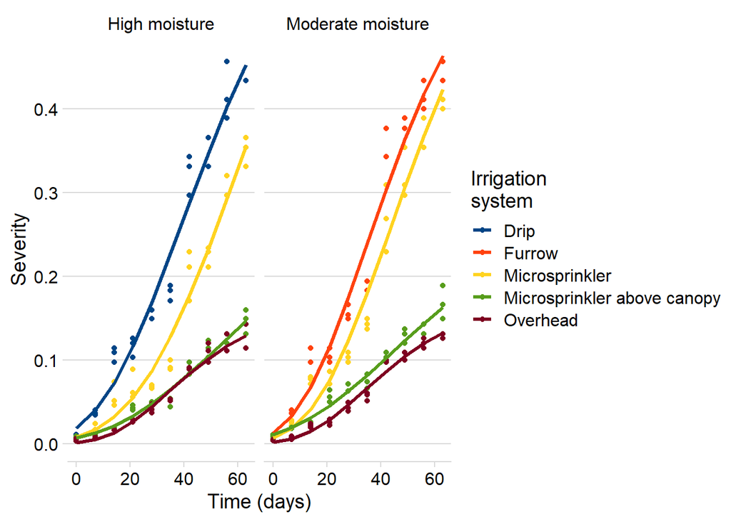

```r
curves = fit_pd$Data %>%
  filter(model == "Gompertz") %>%
  ggplot(aes(color = irrigation_type))+
  geom_point(aes(time, y))+
  geom_line(aes(time, predicted),
            size = 1.2)+
  scale_color_calc()+
  facet_wrap(~moisture, ncol =2)+
  theme_minimal_hgrid()+
  labs(y = "Severity",
       x = "Time (days)",
        color = "Irrigation \nsystem")
curves
```

#### Residuals

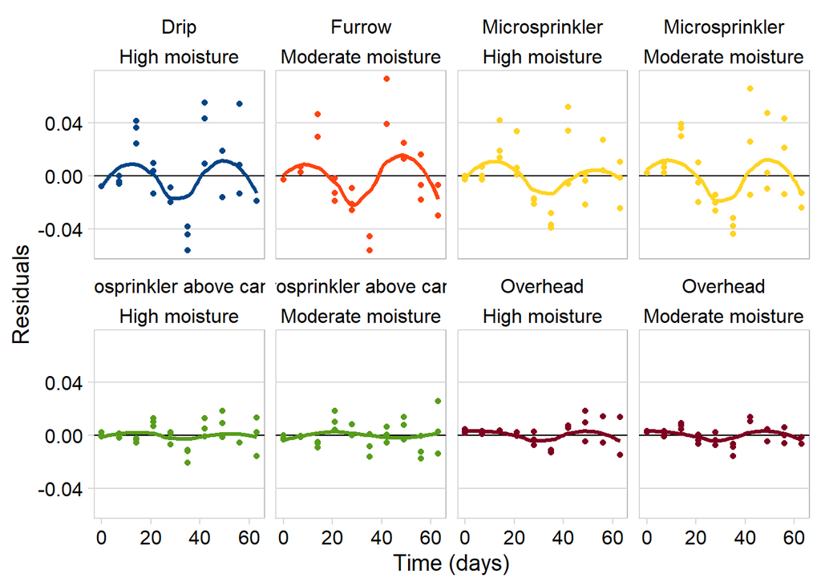

```r
resid = fit_pd$Data %>%
  filter(model == "Gompertz") %>%
  ggplot(aes(time, residual, color = irrigation_type))+
  geom_hline(yintercept = 0)+
  geom_point()+
  geom_smooth(se=F,
            size = 1.2)+
  scale_color_calc()+
  facet_wrap(irrigation_type~moisture, ncol = 4)+
  theme_minimal_hgrid()+
  labs(y = "Residuals",
       x = "Time (days)",
        color = "Irrigation \nsystem")+
  theme(legend.position = "none",
        panel.background = element_rect(color = "gray"))
resid
```

#### Combo figure

We buit a combo figure for publication. We use package `patchwork` for that.

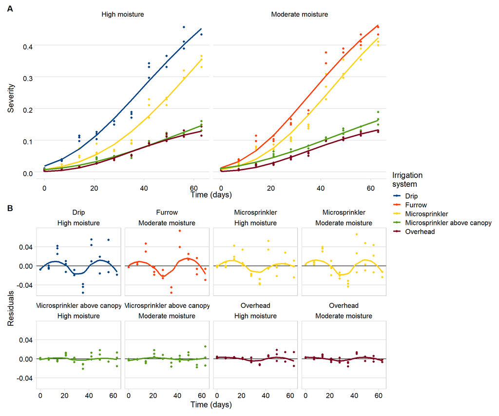

```r
curves/resid +
  plot_layout(guides = "collect")+
  plot_annotation(tag_levels = "A")
```

```r
ggsave("figs/fitting_Actual.png", dpi = 300,height = 10,width = 14)
```

### Goodness of fit

Here we present the goodness of fit of the gompertz model.

```r
fit_pd$Parameters %>%
  dplyr::select(irrigation_type, moisture, model, CCC, RSE, r_squared) %>%
  # pivot_longer(4:6,
  #              names_to = "stats",
               # values_to = "value") %>%
  filter(model == "Gompertz")%>%
  arrange(desc(irrigation_type))
```

| irrigation_type | moisture | model | CCC | RSE | r_squared |
| --- | --- | --- | --- | --- | --- |
| Overhead | High moisture | Gompertz | 0.9830257 | 0.008745389 | 0.9665070 |
| Overhead | Moderate moisture | Gompertz | 0.9897830 | 0.006907156 | 0.9798217 |
| Microsprinkler above canopy | High moisture | Gompertz | 0.9827796 | 0.009159126 | 0.9660976 |
| Microsprinkler above canopy | Moderate moisture | Gompertz | 0.9827771 | 0.009997810 | 0.9663270 |
| Microsprinkler | High moisture | Gompertz | 0.9825038 | 0.022901949 | 0.9654614 |
| Microsprinkler | Moderate moisture | Gompertz | 0.9825371 | 0.028191586 | 0.9655249 |
| Furrow | Moderate moisture | Gompertz | 0.9834864 | 0.029846442 | 0.9673484 |
| Drip | High moisture | Gompertz | 0.9833178 | 0.028503244 | 0.9671276 |

# Simulation based on actual data

We used the parameters estimated for the treatments for simulating disease progress cruves. Since the Gompertz model was the best model, we used the `sim_gompertz()` function from epifitter for simulating curves for each treatment. To inset variation into the simulated data, we use `alpha = 0.1`. Use `?sim_gompertz` for details.

```r
par_best_model = fit_pd$Parameters %>%
  filter(model=="Gompertz")
epi_box = NULL
for(i in 1:length(par_best_model$irrigation_type)){
epi_sim = sim_gompertz(N = 63,
             dt = 7,
             y0 = par_best_model$y0[i],
             r = par_best_model$r[i],
             K = par_best_model$K[i],
             n = 4,
             alpha = 0.1)

   epinho_box =  data.frame(irrigation_type = par_best_model$irrigation_type[i],
         moisture = par_best_model$moisture[i], epi_sim)
   epi_box = epi_box%>%
     bind_rows(epinho_box)
}
```

#### Simulated curves.

See the comparative between the simulated data (dots) and the fitted curves (lines).

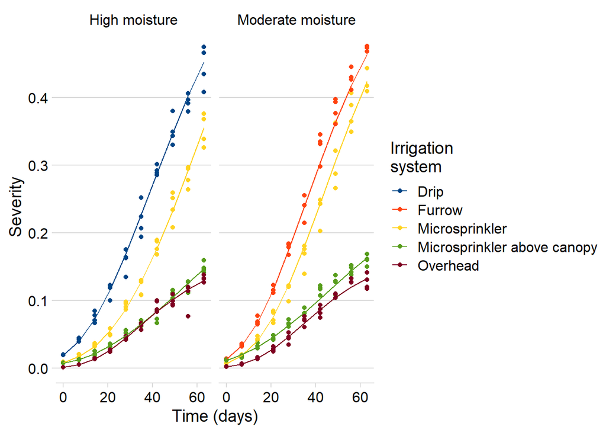

```r
epi_box %>%
  ggplot()+
  geom_point(aes(time, random_y, color = irrigation_type))+
  geom_line(data = fit_pd$Data %>% filter(model=="Gompertz"),
            aes(time, predicted, color = irrigation_type))+
  facet_wrap(~moisture) +
  scale_color_calc()+
  theme_minimal_hgrid()+
  labs(y = "Severity",
       x = "Time (days)",
        color = "Irrigation \nsystem")
```

```r
ggsave("figs/simulation_Actual.png", dpi = 300,height = 4,width = 8)
```

# Simulating DPCs for different models

### The exponential model

```r
exp_model <- sim_exponential(
  N = 100,
  y0 = 0.01,
  dt = 5,
  r = 0.045,
  alpha = 0.2,
  n = 7
)
head(exp_model)
```

|  | replicates | time | y | random_y |
| --- | --- | --- | --- | --- |
| 1 | 1 | 0 | 0.01000000 | 0.01189065 |
| 2 | 1 | 5 | 0.01252459 | 0.01191603 |
| 3 | 1 | 10 | 0.01568619 | 0.01823657 |
| 4 | 1 | 15 | 0.01964549 | 0.02201059 |
| 5 | 1 | 20 | 0.02460372 | 0.03138000 |
| 6 | 1 | 25 | 0.03081292 | 0.03563682 |

The function returns a `data.frame` object with four columns. `replicates` indicate each respective replicate, in `time` we have the time steps, `y` contains the simulated values of disease intensity, and `random_y` contains values of disease intensity after inserting a variation.

Use the [`ggplot2`](https://ggplot2.tidyverse.org/) package to build impressive graphics!

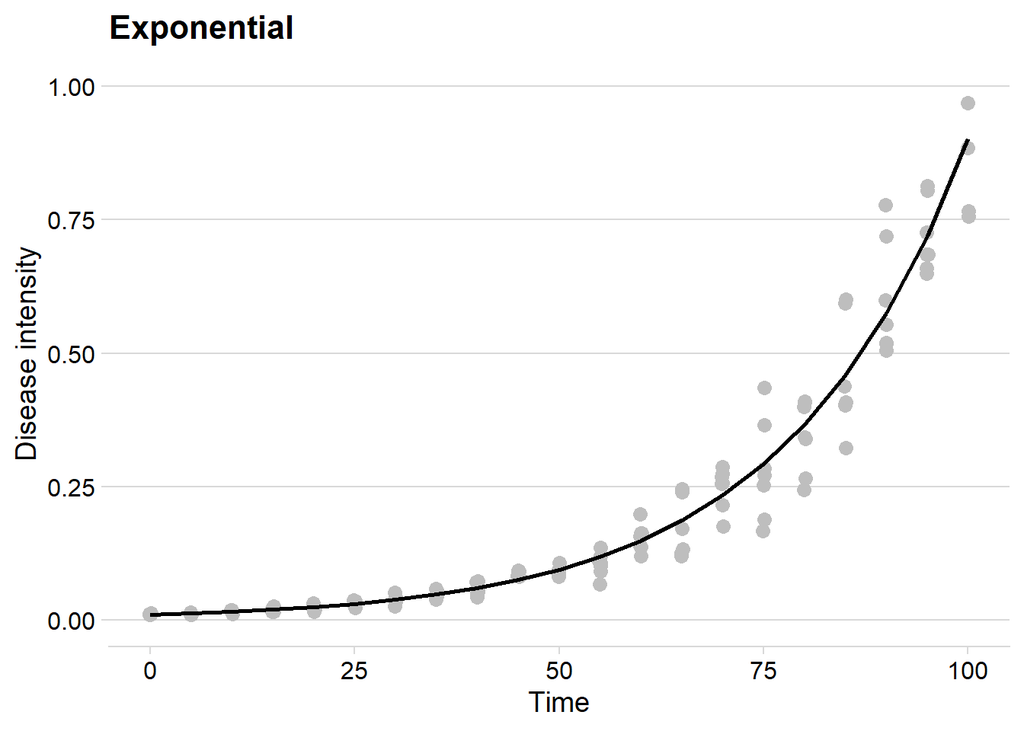

```r
exp_plot = exp_model %>%
  ggplot(aes(time, y)) +
  geom_jitter(aes(time, random_y), size = 3,color = "gray", width = .1) +
  geom_line(size = 1) +
  theme_minimal_hgrid() +
  ylim(0,1)+
  labs(
    title = "Exponential",
    y = "Disease intensity",
    x = "Time"
  )
exp_plot
```

### The Monomolecular model

For the other models is exactly the same pipeline.

```r
mono_model <- sim_monomolecular(
  N = 100,
  y0 = 0.01,
  dt = 5,
  r = 0.05,
  alpha = 0.2,
  n = 7
)
head(mono_model)
```

|  | replicates | time | y | random_y |
| --- | --- | --- | --- | --- |
| 1 | 1 | 0 | 0.0100000 | 0.0111279 |
| 2 | 1 | 5 | 0.2289861 | 0.1812466 |
| 3 | 1 | 10 | 0.3995322 | 0.3689962 |
| 4 | 1 | 15 | 0.5323535 | 0.5058101 |
| 5 | 1 | 20 | 0.6357949 | 0.6793221 |
| 6 | 1 | 25 | 0.7163551 | 0.6855234 |

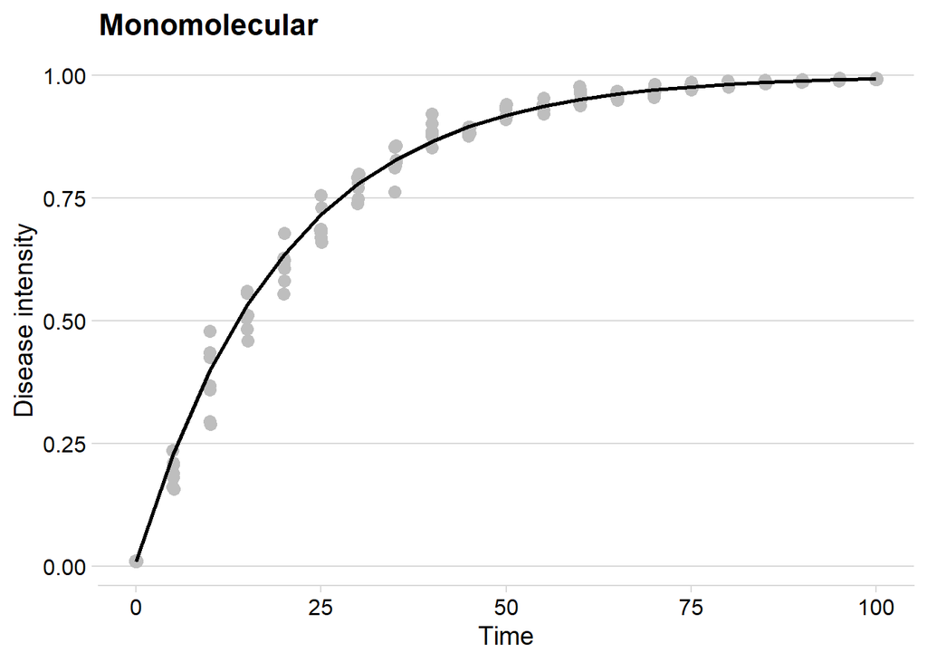

```r
mono_plot = mono_model %>%
  ggplot(aes(time, y)) +
  geom_jitter(aes(time, random_y), size = 3, color = "gray", width = .1) +
  geom_line(size = 1) +
  theme_minimal_hgrid() +
  labs(
    title = "Monomolecular",
    y = "Disease intensity",
    x = "Time"
  )
mono_plot
```

### The Logistic model

```r
logist_model <- sim_logistic(
  N = 100,
  y0 = 0.01,
  dt = 5,
  r = 0.1,
  alpha = 0.2,
  n = 7
)
head(logist_model)
```

|  | replicates | time | y | random_y |
| --- | --- | --- | --- | --- |
| 1 | 1 | 0 | 0.01000000 | 0.01000000 |
| 2 | 1 | 5 | 0.01638216 | 0.01385962 |
| 3 | 1 | 10 | 0.02672677 | 0.02215542 |
| 4 | 1 | 15 | 0.04331509 | 0.04009378 |
| 5 | 1 | 20 | 0.06946352 | 0.08839565 |
| 6 | 1 | 25 | 0.10958806 | 0.10024173 |

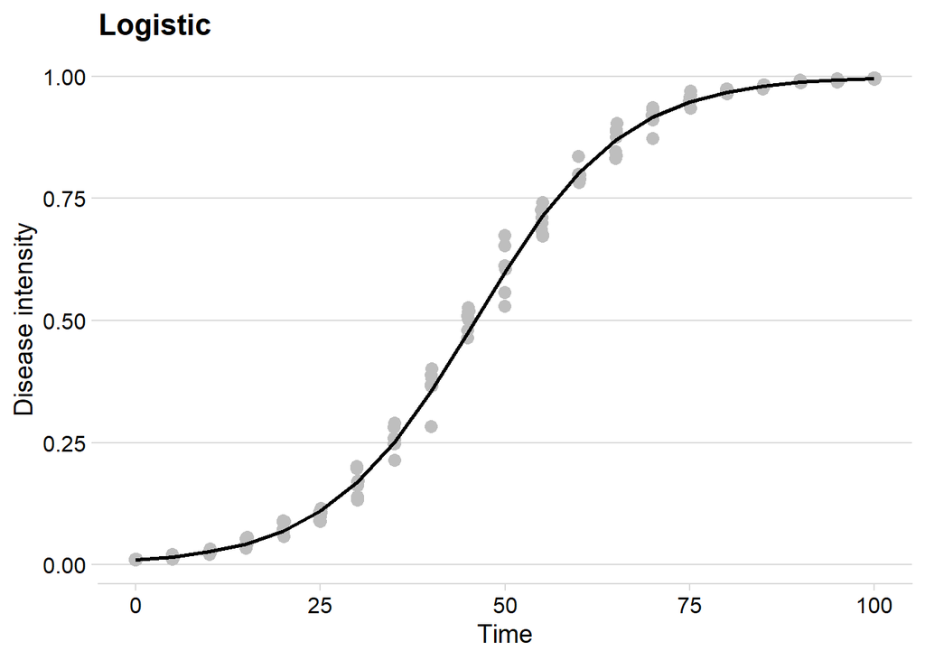

```r
logist_plot = logist_model %>%
  ggplot(aes(time, y)) +
  geom_jitter(aes(time, random_y), size = 3,color = "gray", width = .1) +
  geom_line(size = 1) +
  theme_minimal_hgrid() +
  labs(
    title = "Logistic",
    y = "Disease intensity",
    x = "Time"
  )
logist_plot
```

### The Gompertz model

```r
gomp_model <- sim_gompertz(
  N = 100,
  y0 = 0.01,
  dt = 5,
  r = 0.07,
  alpha = 0.2,
  n = 7
)
head(gomp_model)
```

|  | replicates | time | y | random_y |
| --- | --- | --- | --- | --- |
| 1 | 1 | 0 | 0.01000000 | 0.0100000 |
| 2 | 1 | 5 | 0.03896283 | 0.0427471 |
| 3 | 1 | 10 | 0.10158896 | 0.1153201 |
| 4 | 1 | 15 | 0.19958740 | 0.1416333 |
| 5 | 1 | 20 | 0.32122825 | 0.2681490 |
| 6 | 1 | 25 | 0.44922018 | 0.4072825 |

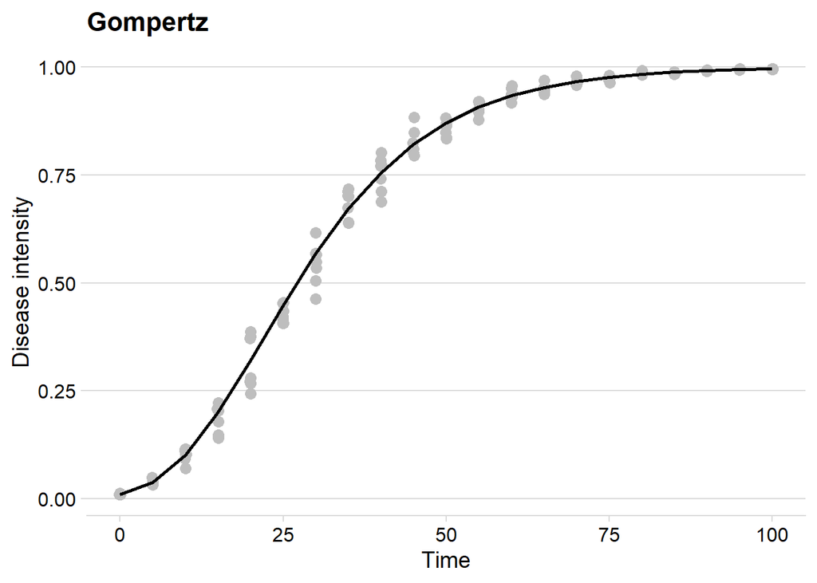

```r
gomp_plot = gomp_model %>%
  ggplot(aes(time, y)) +
  geom_jitter(aes(time, random_y), size = 3,color = "gray", width = .1) +
  geom_line(size = 1) +
  theme_minimal_hgrid() +
  labs(
    title = "Gompertz",
    y = "Disease intensity",
    x = "Time"
  )
gomp_plot
```

## Combo

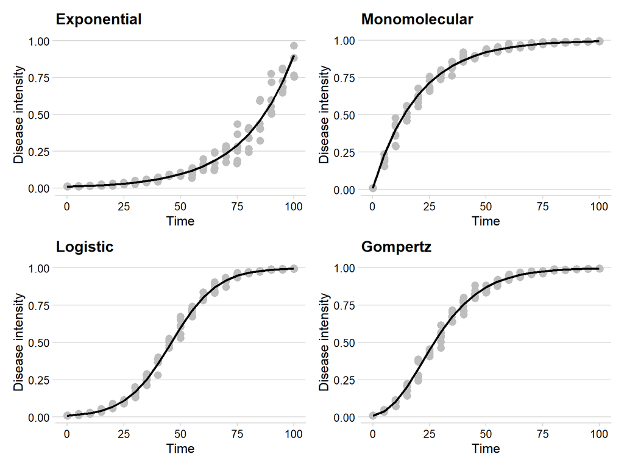

```r
exp_plot+mono_plot+logist_plot+gomp_plot&
  theme_minimal_hgrid(font_size = 12)
```

```r
ggsave("figs/simulation.png", dpi = 800, height = 6, width = 9)
```

## AUDPC and AUDPS

```r
# Simulating epidemic:
epi = sim_logistic(N = 30, y0 = 0.01,dt = 5, r = 0.3, alpha = 0.5, n = 1)


# Calculating AUDPC:
AUDPC(time = epi$time, y = epi$y)
```

```
## [1] 14.69147
```

```r
# Calculating AUDPA:
AUDPS(time = epi$time, y = epi$y)
```

```
## [1] 17.1863
```

## Model fitting

We simulate a epidemic to use in for model fitting

```r
sim_logistic(N = 10, y0 = 0.1, dt = 1, r = 0.3, alpha = 0.1, n = 1)
```

| replicates | time | y | random_y |
| --- | --- | --- | --- |
| 1 | 0 | 0.1000000 | 0.1092301 |
| 1 | 1 | 0.1304217 | 0.1026437 |
| 1 | 2 | 0.1683682 | 0.1640490 |
| 1 | 3 | 0.2146309 | 0.2344824 |
| 1 | 4 | 0.2694812 | 0.2745798 |
| 1 | 5 | 0.3324195 | 0.3470335 |
| 1 | 6 | 0.4019695 | 0.3900380 |
| 1 | 7 | 0.4757028 | 0.4836783 |
| 1 | 8 | 0.5505094 | 0.5411913 |
| 1 | 9 | 0.6231015 | 0.6115384 |

[output cut: 1 more lines]

```r
set.seed(1)
epi = sim_logistic(N = 30, y0 = 0.1,dt = 5, r = 0.3, alpha = 0.5, n = 4)
fit_lin(time = epi$time, y = epi$random_y)
```

```
## Results of fitting population models
##
## Stats:
##                  CCC r_squared    RSE
## Logistic      0.9863    0.9729 0.5080
## Gompertz      0.9823    0.9653 0.5075
## Monomolecular 0.9743    0.9498 0.5513
## Exponential   0.8485    0.7369 0.3860
##
##  Infection rate:
##                 Estimate   Std.error      Lower      Upper
## Logistic      0.29333694 0.009600241 0.27360336 0.27360336
## Gompertz      0.25782957 0.009591244 0.23811448 0.23811448
## Monomolecular 0.23108256 0.010419214 0.20966556 0.20966556
## Exponential   0.06225438 0.007294680 0.04725995 0.04725995
##
##  Initial inoculum:
##                  Estimate Linearized    lin.SE       Lower      Upper
## Logistic       0.12318338 -1.9626237 0.1730708  0.08961247  0.1670234
## Gompertz       0.04450738 -1.1352978 0.1729086  0.01179268  0.1129050
## Monomolecular -0.65582201 -0.5042976 0.1878350 -1.43609912 -0.1254659
## Exponential    0.23262533 -1.4583262 0.1315067  0.17752531  0.3048272
```

```r
set.seed(12)
epi = sim_logistic(N = 30, y0 = 0.1,dt = 3, r = 0.3, alpha = 0.5, n =4)
fit_lin(time = epi$time, y = epi$random_y)
```

```
## Results of fitting population models
##
## Stats:
##                  CCC r_squared    RSE
## Logistic      0.9920    0.9840 0.3766
## Gompertz      0.9861    0.9726 0.4337
## Monomolecular 0.9749    0.9511 0.5236
## Exponential   0.8438    0.7298 0.3938
##
##  Infection rate:
##                 Estimate   Std.error      Lower      Upper
## Logistic      0.30444058 0.005984742 0.29236288 0.29236288
## Gompertz      0.26628474 0.006892538 0.25237503 0.25237503
## Monomolecular 0.23778221 0.008321126 0.22098950 0.22098950
## Exponential   0.06665837 0.006257747 0.05402972 0.05402972
##
##  Initial inoculum:
##                  Estimate Linearized    lin.SE        Lower       Upper
## Logistic       0.09158756 -2.2944030 0.1062186  0.075246284  0.11105151
## Gompertz       0.01595919 -1.4201450 0.1223304  0.005009851  0.03945663
## Monomolecular -1.13464606 -0.7583009 0.1476853 -1.875831732 -0.58448554
## Exponential    0.21521835 -1.5361022 0.1110640  0.172003856  0.26929012
```

# Plot_fit

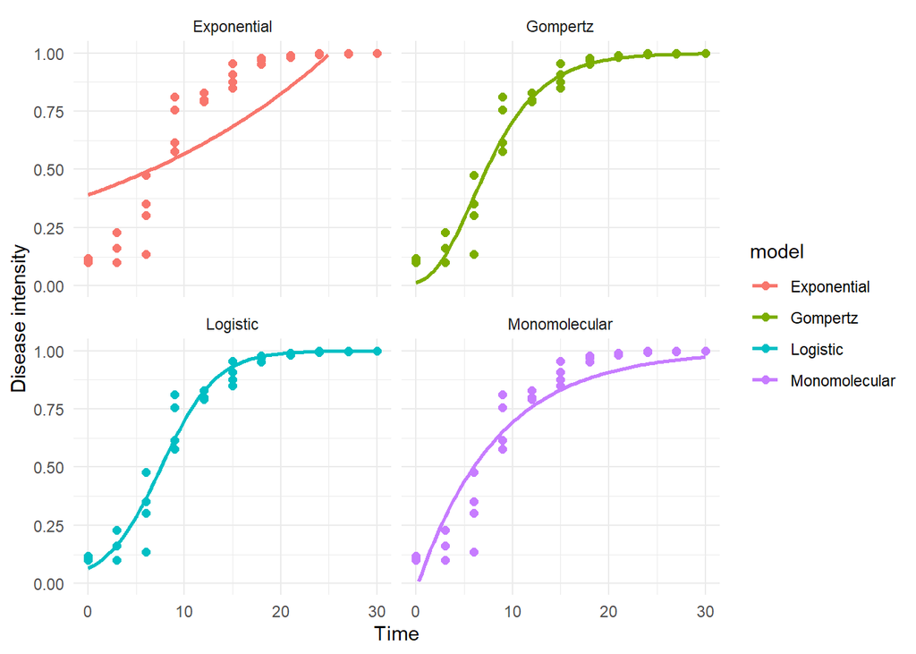

```r
set.seed(1)
epi = sim_logistic(N = 30, y0 = 0.1,dt = 3, r = 0.3, alpha = 0.5, n =4)
model_fit = fit_nlin(time = epi$time, y = epi$random_y)
plot_fit(model_fit,point_size = 2, line_size = 1) +
  theme_minimal()+
  ylim(0,1)+
  labs(x = "Time", y = "Disease intensity")
```

```r
ggsave("figs/plotfit.png", dpi = 800, height  = 5, width = 7)
```